# Advanced Bioinformatics 2021 assessment

18047

11/04/2021

| # Task 3.1 |
| --- |

sum of all intergers between 5 and 55 sum() add all values within ()

‘:’ includes values from:to

```r
x <-sum(5:55); x
```

```
## [1] 1530
```

| # Task 3.2 |
| --- |

write function *sumfun* with one input parameter *n* that calculate sum of all integers between 5 and *n*

use function *n* to calculate n= 10, n= 20, n=100

```r
sumfun <- function(n){
  n <- sum(5:n)
  return(n)
}
```

write function *sumfun* to parameter *n* n = the sum of integers from 5 to parameter *n* return the value of parameter n when sumfun function is used

sumfun returns calculation when give parameter n=

n=10

```r
sumfun(10)
```

```
## [1] 45
```

n= 20

```r
sumfun(20)
```

```
## [1] 200
```

n=100

```r
sumfun(100)
```

```
## [1] 5040
```

[output not shown]

## #Task 3.4

```r
#install and load ggplot2

install.packages("ggplot2",repos = "https://cran.rstudio.com/bin/macosx/contrib/4.0/ggplot2_3.3.3.tgz")
library (ggplot2)
```

```r
#load data
data(mtcars)

#view first 6 rows of data
head(mtcars)
```

```
##                    mpg cyl disp  hp drat    wt  qsec vs am gear carb
## Mazda RX4         21.0   6  160 110 3.90 2.620 16.46  0  1    4    4
## Mazda RX4 Wag     21.0   6  160 110 3.90 2.875 17.02  0  1    4    4
## Datsun 710        22.8   4  108  93 3.85 2.320 18.61  1  1    4    1
## Hornet 4 Drive    21.4   6  258 110 3.08 3.215 19.44  1  0    3    1
## Hornet Sportabout 18.7   8  360 175 3.15 3.440 17.02  0  0    3    2
## Valiant           18.1   6  225 105 2.76 3.460 20.22  1  0    3    1
```

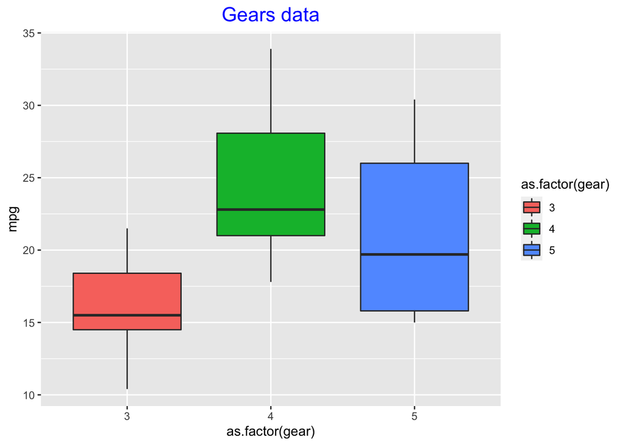

| #Task 3.5 |
| --- |

```r
# draw ggplot box plot using mtcars dataset of miles per gallon in variable mpg
# as a function of the number of gears in variable (gear)
#fill aesthetic to color bars by number of gears

ggplot(mtcars,aes(x=as.factor(gear), y=mpg, fill=as.factor(gear))) + geom_boxplot() + labs(title = "Gears data") + theme(plot.title = element_text(color = "blue", size= 16, hjust = 0.5))
```

```r
#load dataset cars
data(cars)

#view first few rows of cars
head(cars)
```

```
##   speed dist
## 1     4    2
## 2     4   10
## 3     7    4
## 4     7   22
## 5     8   16
## 6     9   10
```

```r
#fit linear regression line model with y= breaking distance and x=cars
fit <- lm(formula = dist~speed, data=cars)

#show summary of regression line

summary(fit)
```

```
##
## Call:
## lm(formula = dist ~ speed, data = cars)
##
## Residuals:
##     Min      1Q  Median      3Q     Max
## -29.069  -9.525  -2.272   9.215  43.201
##
## Coefficients:
##             Estimate Std. Error t value Pr(>|t|)
## (Intercept) -17.5791     6.7584  -2.601   0.0123 *
## speed         3.9324     0.4155   9.464 1.49e-12 ***
## ---
## Signif. codes:  0 '***' 0.001 '**' 0.01 '*' 0.05 '.' 0.1 ' ' 1
##
## Residual standard error: 15.38 on 48 degrees of freedom
## Multiple R-squared:  0.6511, Adjusted R-squared:  0.6438
## F-statistic: 89.57 on 1 and 48 DF,  p-value: 1.49e-12
```

```r
#Intercept= -17.5791, slope= 3.9324, standard errors for intercept: 6.7584, standard errors for slope: 0.4155)

#variables used speed= mph, dist = ft
help(cars)
```

| #Task 3.6 |
| --- |

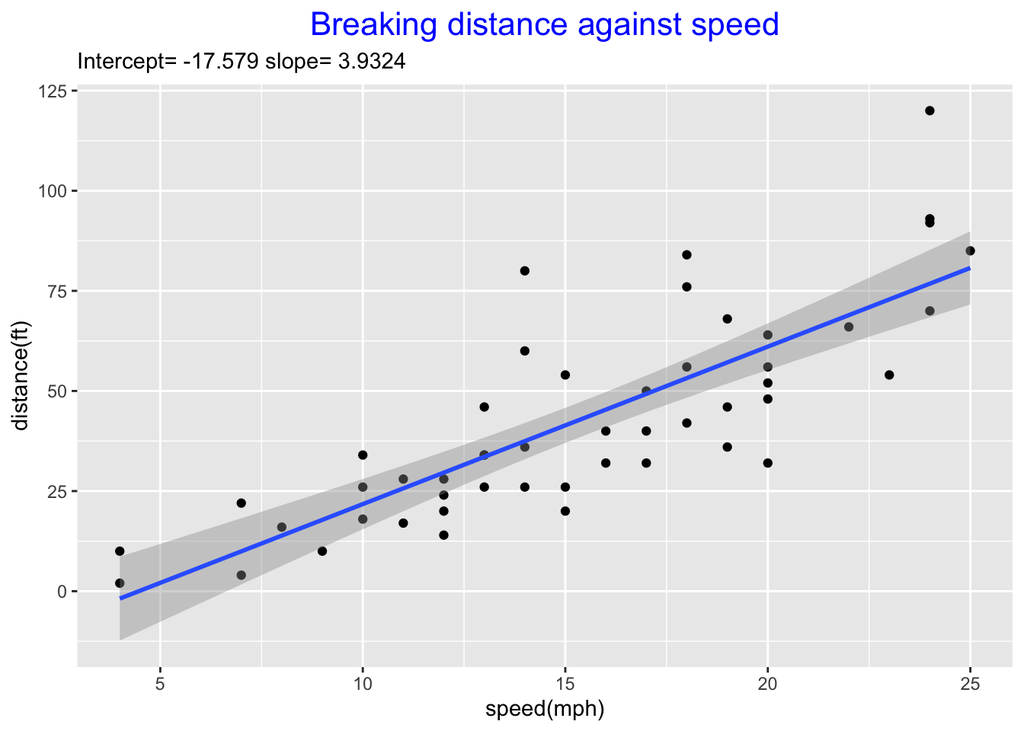

| #Task 3.7 |
| --- |

```r
#task 6? useing the lm best fit line from task 3.5
#plot scatterplot and best fit line between speed and breaking distance

ggplot(cars,aes(speed,dist)) + geom_point() +
  geom_smooth(method = "lm",formula = "y~x") +
  labs(title = "Breaking distance against speed", subtitle = paste("Intercept=",signif(fit$coefficients[[1]],5),
                     "slope=",signif(fit$coefficients[[2]],5))) +
  theme(plot.title = element_text(colour = "blue", size = 16, hjust = 0.5)) +
  xlab("speed(mph)") + ylab("distance(ft)")
```

- use lm to estimate average reaction time of driver to start breaking in seconds using lm line between dist(ft) and speed^2 (ft/sec)

important info.

- assume reaction time is proportional to time diver applies breaks and once breaking commences breaking distance is proportional to square of speed

*1 mile = 5280 ft

*1 hour = 3600 sec

convert speed from mile per hour to sec per ft view summary and see average of reaction time at y-intercept of lm line

```r
# cars database already loaded

#convert speed (mph) to (sec/ft)= speed (mph) * (5280/3600)
#reaction time is assumed to be equal to breaking distance
# and breaking distance is equal to speed^2
#do calculation and save to new column of cars as speed_new
cars$speed_new <- cars[,1]*(5280/3600)^2

#see if column has been made
head (cars)
```

```
##   speed dist speed_new
## 1     4    2  8.604444
## 2     4   10  8.604444
## 3     7    4 15.057778
## 4     7   22 15.057778
## 5     8   16 17.208889
## 6     9   10 19.360000
```

```r
# new liner model line,
line <- lm(formula = dist~speed_new, data = cars)
summary(line)
```

```
##
## Call:
## lm(formula = dist ~ speed_new, data = cars)
##
## Residuals:
##     Min      1Q  Median      3Q     Max
## -29.069  -9.525  -2.272   9.215  43.201
##
## Coefficients:
##             Estimate Std. Error t value Pr(>|t|)
## (Intercept) -17.5791     6.7584  -2.601   0.0123 *
## speed_new     1.8281     0.1932   9.464 1.49e-12 ***
## ---
## Signif. codes:  0 '***' 0.001 '**' 0.01 '*' 0.05 '.' 0.1 ' ' 1
##
## Residual standard error: 15.38 on 48 degrees of freedom
## Multiple R-squared:  0.6511, Adjusted R-squared:  0.6438
## F-statistic: 89.57 on 1 and 48 DF,  p-value: 1.49e-12
```

```r
#the slope is around 1.8281 as a reaction time in seconds seems acceptable, google searches estimate average breaking times to be around 0.7 ~ 3 secs
#y-intercept is not always a good indicated like in this case it stats going at 0 ft/sec it goes backwards, and can be ignored.
```

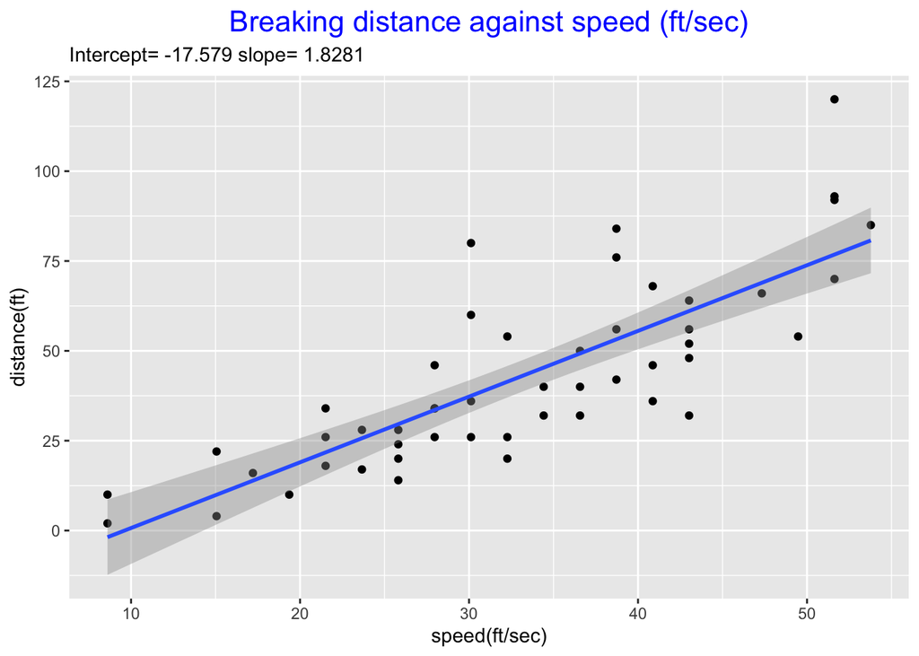

```r
#plot new scatterplot with new lm line in ft

y <-cars$speed_new
x <-cars$dist

ggplot(cars,aes(speed_new,dist)) + geom_point()+
  geom_smooth(method = "lm",formula = "y~x")+ labs(title = "Breaking distance against speed (ft/sec)", subtitle = paste("Intercept=",signif(fit$coefficients[[1]],5),             "slope=",signif(line$coefficients[[2]],5)))+
  theme(plot.title = element_text(colour = "blue", size = 16, hjust = 0.5))+
  xlab("speed(ft/sec)") + ylab("distance(ft)")
```